# Practical F

Jolien Cremers

Statistical Programming with R

The purpose of this practical is to use some of R’s packages to solve a missing data problem by imputing missing values in a ‘real’ dataset. This can either be a dataset you’ve brought to this course yourself or the `selfreport` data from the `mice` package. The ‘selfreport’ data is described in Section 7.3 of the first edition of the book Flexible Imputation of Missing Data (van Buuren, S. (2012). *Flexible Imputation of Missing Data.* CRC/Chapman & Hall, FL: Boca Raton).

Suggested packages:

```r
library(mice) # for visualisation & pmm
library(VIM) # visualisation & several hotdeck imputation methods (fast implementation)
library(simputation) # common interface for several imputation methods
library(magrittr) # for pipe operator
library(dplyr)
library(naniar) # additional package for practical
library(visdat) # visualisation of datasets
library(UpSetR) # Upset plots
library(ggplot2) # plots
```

#### Selfreport data

The selfreport data contains data from two studies, one from the `mgg` study, the *survey dataset*, where height and weight are selfreported measures (`hr` and `wr`) and one from the `krul` study, the *calibration dataset*, where the height and weight measures are both selfreported and measured (variables `hm` and `wm`). The goal for the self-report data is to obtain correct estimates of the prevalence of obesity (Body Mass Index > 32) in the *survey dataset*. Note that the Body Mass Index (bmi) is computed as follows:

$$\text{bmi} = \frac{\text{weight in kg}}{(\text{height in m})^2}$$

1. **Check missing data patterns.**

First, check if there is a description of the `selfreport` data in the `mice` package documentation:

```r
?selfreport
```

```
## starting httpd help server ... done
```

The selfreport data contains data from two studies, one from the `mgg` study where height and weight are selfreported measures (`hr` and `wr`) and one from the `krul` study where the measures are both selfreported and measured (variables `hm` and `wm`).

Then, investigate the missing data patterns

```r
head(selfreport, n = 10)
```

```
##    src    id pop age    sex hm wm  hr  wr          prg    edu        etn
## 1  mgg 10001  NL  27   Male NA NA 190  85         <NA> Middle Autochtone
## 2  mgg 10002  NL  38   Male NA NA 189  93         <NA>    Low Autochtone
## 3  mgg 10003  NL  21   Male NA NA 200 110         <NA>    Low Autochtone
## 4  mgg 10004  NL  52   Male NA NA 176  80         <NA>    Low Autochtone
## 5  mgg 10005  NL  44   Male NA NA 183  79         <NA> Middle Autochtone
## 6  mgg 10006  NL  31 Female NA NA 167  80 Not pregnant Middle Autochtone
## 7  mgg 10007  NL  42 Female NA NA 187  73 Not pregnant   High Autochtone
## 8  mgg 10008  NL  39   Male NA NA 180  85         <NA>   High Allochtone
## 9  mgg 10009  NL  36 Female NA NA 178  70 Not pregnant Middle Autochtone
## 10 mgg 10010  NL  38 Female NA NA 174  55 Not pregnant   High Allochtone
##    web bm       br
## 1   No NA 23.54571
## 2   No NA 26.03511
## 3   No NA 27.50000
## 4   No NA 25.82645
## 5   No NA 23.58984
## 6   No NA 28.68514
## 7   No NA 20.87563
## 8   No NA 26.23457
## 9   No NA 22.09317
## 10  No NA 18.16620
```

```r
summary(selfreport)
```

```
##    src             id        pop            age            sex
##  krul:1257   Min.   :10001   NL:2060   Min.   :18.00   Female:1098
##  mgg : 803   1st Qu.:10612   IT:   0   1st Qu.:29.00   Male  : 962
##              Median :12302   US:   0   Median :41.00
##              Mean   :13299             Mean   :42.06
##              3rd Qu.:15958             3rd Qu.:54.00
##              Max.   :17079             Max.   :75.00
##
##        hm              wm              hr              wr
##  Min.   :143.6   Min.   : 44.0   Min.   :143.0   Min.   : 30.00
##  1st Qu.:166.5   1st Qu.: 66.0   1st Qu.:168.0   1st Qu.: 66.00
##  Median :173.3   Median : 75.8   Median :175.0   Median : 75.20
##  Mean   :174.0   Mean   : 77.8   Mean   :174.9   Mean   : 77.79
##  3rd Qu.:181.1   3rd Qu.: 86.6   3rd Qu.:182.0   3rd Qu.: 87.00
##  Max.   :207.3   Max.   :149.7   Max.   :214.0   Max.   :165.00
##  NA's   :803     NA's   :803
##                      prg           edu               etn        web
##  Pregnant              :   0   Low   : 286   Autochtone: 657   No :1858
##  Delivery last 6 months:   0   Middle: 323   Allochtone: 146   Yes: 202
##  Not pregnant          : 403   High  : 194   Unknown   :   0
##  NA's                  :1657   NA's  :1257   NA's      :1257
##
##
##
##        bm              br
##  Min.   :16.83   Min.   :10.76
##  1st Qu.:21.98   1st Qu.:22.08
##  Median :24.64   Median :24.71
##  Mean   :25.68   Mean   :25.39
##  3rd Qu.:28.12   3rd Qu.:27.67
##  Max.   :55.17   Max.   :52.08
##  NA's   :803
```

The measures weight and height variables are indeed missing from the `mgg` study

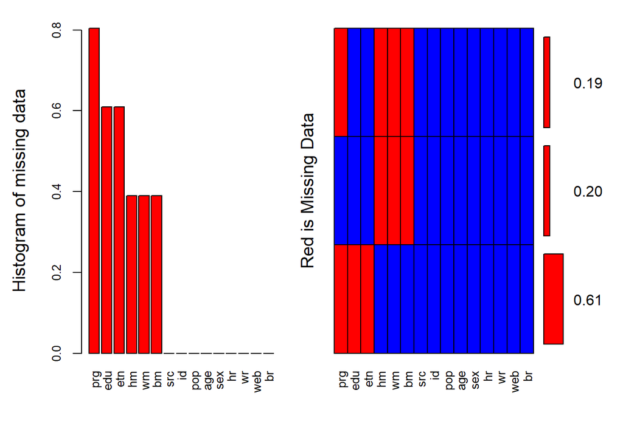

```
##
##  Variables sorted by number of missings:
##  Variable     Count
##       prg 0.8043689
##       edu 0.6101942
##       etn 0.6101942
##        hm 0.3898058
##        wm 0.3898058
##        bm 0.3898058
##       src 0.0000000
##        id 0.0000000
##       pop 0.0000000
##       age 0.0000000
##       sex 0.0000000
##        hr 0.0000000
##        wr 0.0000000
##       web 0.0000000
##        br 0.0000000
```

```r
VIM::aggr(selfreport, col=c('blue','red'), numbers=TRUE, sortVars=TRUE,
                  labels=names(selfreport), cex.axis=.8, gap=3,
                  ylab=c("Histogram of missing data", "Red is Missing Data"))
```

Apart from measured height and weight also the measured bmi, the indicators for pregnancy, educational level and ethnicity contain missing values.

2. **Check the relation between measured and self reported bmi in the *calibration dataset*.**

There are more individuals that have a lower selfreported BMI than measured BMI.

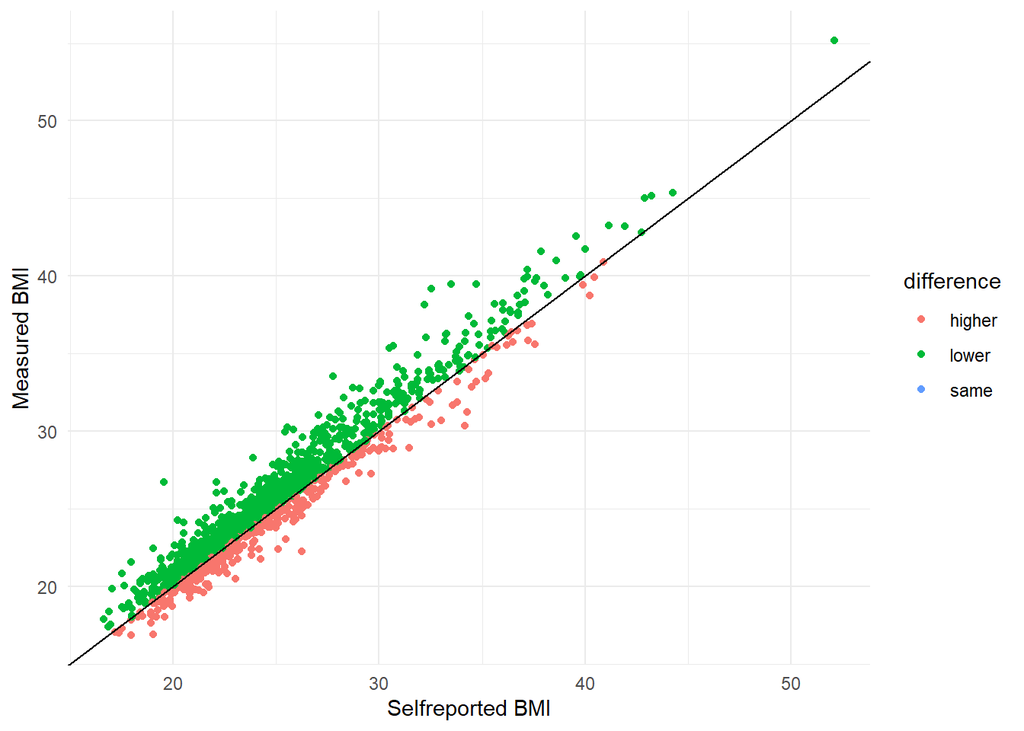

```r
calibration <- selfreport %>%
  filter(as.numeric(src) == 1) %>%
  mutate(difference = case_when(br < bm ~ "lower",
                                bm < br ~ "higher",
                                bm == br ~ "same"))

ggplot(calibration, aes(br, bm, color = difference)) +
  geom_point() +
  theme_minimal() +
  geom_abline(intercept = 0, slope = 1) +
  labs(x = "Selfreported BMI", y = "Measured BMI", fill = "")
```

3. **Impute missing data.**

First define a deterministic function to compute bmi:

```r
bmi <- function(h, w) {
  return(w/(h/100)^2)
}
```

Define the imputation methods to use (we only impute `wm`, `hm` and `bm`). Make sure to define the deterministic relation between height, weight and bmi for the computation (not imputation) of bmi.

```r
meth <- c(rep("", 5), "pmm", "pmm", rep("", 6), "~bmi(hm,wm)", "")
```

Get predictor matrix:

```r
init <- mice(selfreport, maxit = 0) #get initial predictor matrix
pred <- init$pred #note that pregnancy is not imputed by default because it contains too many missings
pred[, c("src", "id", "pop", "prg", "edu", "etn", "web", "bm", "br")] <- 0 #set variables not used as predictors to 0
```

Impute:

```r
imp <- mice(selfreport, pred = pred, meth = meth, seed = 66573, maxit = 20, m = 10)
```

4. **What is the estimated prevalence (selfreported and imputed data) of obesity for different `age` and `sex` in the *survey dataset*?**

Estimated prevalence in the selfreported data

```r
reported <- as.tbl(selfreport)

reported %>%
  filter(as.numeric(src) == 2) %>%
  mutate(br = bmi(hr, wr)) %>%
  mutate(obese = case_when(br > 32 ~ 1,
                           TRUE ~ 0)) %>%
  mutate(age_cat = cut(age, c(17, 29, 39, 49, 59, 75))) %>%
  group_by(sex, age_cat) %>%
  summarise(N = n(), prevalence = sum(obese)/N*100)
```

```
## # A tibble: 10 x 4
## # Groups:   sex [2]
##    sex    age_cat     N prevalence
##    <fct>  <fct>   <int>      <dbl>
##  1 Female (17,29]    68      10.3
##  2 Female (29,39]    69      14.5
##  3 Female (39,49]    68      13.2
##  4 Female (49,59]    81      17.3
##  5 Female (59,75]   117       4.27
##  6 Male   (17,29]    69       1.45
##  7 Male   (29,39]    73       5.48
##  8 Male   (39,49]    66       4.55
##  9 Male   (49,59]    91      12.1
## 10 Male   (59,75]   101       1.98
```

Estimated prevalence in the imputed data

```r
imputed <- as.tbl(complete(imp, action = "long"))

imputed %>%
  filter(as.numeric(src) == 2) %>%
  mutate(obese = case_when(bm > 32 ~ 1,
                           TRUE ~ 0)) %>%
  mutate(age_cat = cut(age, c(17, 29, 39, 49, 59, 75))) %>%
  group_by(sex, age_cat) %>%
  summarise(N = n()/10, prevalence = sum(obese)/(N*10)*100)
```

```
## # A tibble: 10 x 4
## # Groups:   sex [2]
##    sex    age_cat     N prevalence
##    <fct>  <fct>   <dbl>      <dbl>
##  1 Female (17,29]    68      10.6
##  2 Female (29,39]    69      19.9
##  3 Female (39,49]    68      16.3
##  4 Female (49,59]    81      22.7
##  5 Female (59,75]   117       7.61
##  6 Male   (17,29]    69       2.03
##  7 Male   (29,39]    73       7.67
##  8 Male   (39,49]    66       6.21
##  9 Male   (49,59]    91      14.8
## 10 Male   (59,75]   101       5.54
```

End of practical.